# R Notebook

```r
fpath_data <- "C:/Users/alexi/OneDrive/Bureau/rsys_project/data/log2TPM_tumor_example.Rds"
data <- readRDS(fpath_data)
```

Step 1: pre-filtering the dataset by selecting relevant cells

```r
library(Seurat)
rna_df <- CreateSeuratObject(counts=data)
rna_df <- NormalizeData(rna_df)
```

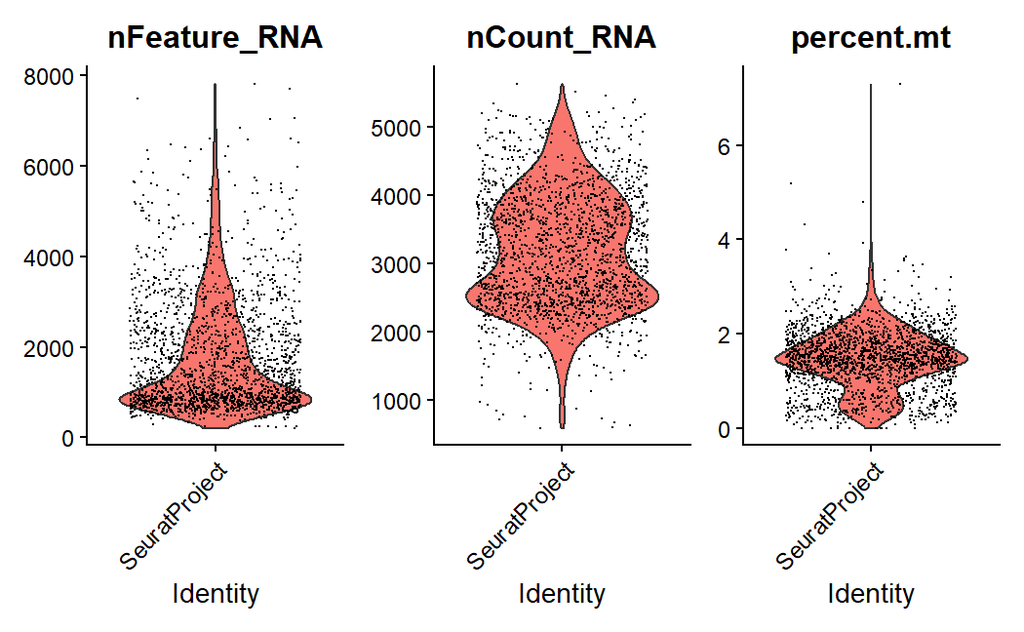

```r
# Visualize QC metrics as a violin plot
# This is done to identify outlayer cells and remove them
rna_df[["percent.mt"]] <- PercentageFeatureSet(rna_df, pattern = "^MT-")
VlnPlot(rna_df, features = c("nFeature_RNA", "nCount_RNA", "percent.mt"), ncol = 3)
```

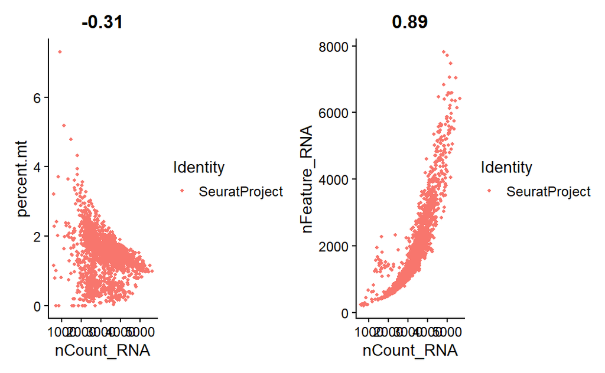

```r
plot1 <- FeatureScatter(rna_df, feature1 = "nCount_RNA", feature2 = "percent.mt")
plot2 <- FeatureScatter(rna_df, feature1 = "nCount_RNA", feature2 = "nFeature_RNA")
plot1 + plot2
```

```r
rna_df <- subset(rna_df, subset = nFeature_RNA < 6000 & percent.mt < 3)
```

```r
variables_features <- FindVariableFeatures(rna_df, selection.method = "vst")
variables_features <- HVFInfo(object = variables_features, assay = "RNA")
selected_features <- subset(variables_features, subset = mean < 3 & mean > 0.0125 & variance.standardized > 0.5)
processed_rna_df <- rna_df[row.names(rna_df) %in% row.names(selected_features), ]
processed_rna_df
```

```
An object of class Seurat
12813 features across 1955 samples within 1 assay
Active assay: RNA (12813 features, 0 variable features)
 2 layers present: counts, data
```

We notice that it reduced the number of genes from 18500 to 12000, but the number of genes remain too important

```r
variables_features <- FindVariableFeatures(rna_df, selection.method = "vst")
# Identify the 10 most highly variable genes
top10 <- head(VariableFeatures(variables_features), 10)

# plot variable features with and without labels
plot1 <- VariableFeaturePlot(variables_features)
plot2 <- LabelPoints(plot = plot1, points = top10, repel = TRUE)
```

```
When using repel, set xnudge and ynudge to 0 for optimal results
```

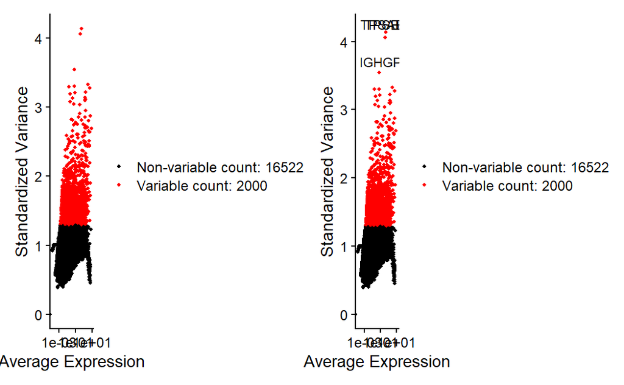

```r
plot1 + plot2
```

Step 2 : feature clustering to identifying differentially expressed genes (DEGs)

To identify DEGs, we need first to determine cell clusters in our dataset. Once we have clusters, we determine, by comparing cell expressions between clusters, which cells are differentially expressed.

```r
# Data has already been scaled, but Seurat PCA function needs a scaled object
all_genes <- rownames(variables_features)
variables_features <- ScaleData(variables_features, features = all_genes)
pca_rna <- RunPCA(variables_features, features = VariableFeatures(object = variables_features))
```

```
PC_ 1
Positive:  B2M, CXCR4, SRGN, TRAC, CD3D, CORO1A, CD52, IL32, CD2, CCL5
       CD3E, TRBC2, PTPRC, RGS1, HLA-B, GZMA, CREM, HCST, BTG1, CYTIP
       CD7, IL2RG, S100A4, CST7, ACAP1, SAMSN1, HLA-C, HLA-A, DUSP4, CD48
Negative:  SLC34A2, WFDC2, MUC1, ELF3, NAPSA, MGST1, CXCL17, CST3, IFITM3, SFTA2
       NPC2, TFPI, CLDN4, EGR1, RNASE1, TACSTD2, C16orf89, SFTPB, SLPI, CYB5A
       MDK, C8orf4, AGR3, IFI27, SOX4, SFTPD, SFTPA1, SCGB3A2, CYR61, KRT18
PC_ 2
Positive:  AIF1, MS4A7, CD68, SPI1, IGSF6, LST1, FCER1G, OLR1, TYROBP, CYBB
       MS4A6A, C1QC, LYZ, C1orf162, MNDA, GPNMB, VSIG4, CSTA, MRC1, C1QA
       RP11-1143G9.4, TREM2, C1QB, TMEM176B, LY86, MARCO, S100A8, HLA-DMB, MSR1, FCGR3A
Negative:  HOPX, SLC34A2, NAPSA, WFDC2, SFTA2, ELF3, KRT18, MUC1, CXCL17, AGR3
       TFPI, TACSTD2, TM4SF1, KRT19, CEACAM6, CLDN4, KRT8, C16orf89, SFTPD, C8orf4
       KRT7, MDK, IFITM2, SLPI, CYR61, AQP5, SOX4, SFTPB, GDF15, C4BPA
PC_ 3
Positive:  SLC34A2, MGST1, ELF3, MUC1, SFTA2, CLDN4, CXCL17, WFDC2, TACSTD2, SFTPB
       AQP3, HOPX, CEACAM6, KRT18, AGR3, NAPSA, SFTPA2, SFTPA1, C4BPA, KRT7
       PIGR, GDF15, SFTPD, SCGB3A2, KRT19, SERPINA1, KRT8, C16orf89, AGR2, AREG
Negative:  BGN, SPARCL1, MFAP4, DCN, AEBP1, LUM, FBLN1, PLAC9, CALD1, FSTL1
       PRELP, COL1A2, SPARC, EMILIN1, MMP2, DPT, COL3A1, PCOLCE, LTBP2, DKK3
       TCF21, ADH1B, COX7A1, COL4A1, FMO2, COL6A2, CDH11, FRZB, RARRES2, COL6A3
PC_ 4
Positive:  TPSAB1, CPA3, MS4A2, TPSB2, GATA2, RGS13, HPGDS, C1orf186, RP11-354E11.2, SLC18A2
       MAOB, LTC4S, IL1RL1, HDC, VWA5A, KIT, GCSAML, SLC45A3, TMEM233, CNRIP1
       CALB2, SVOPL, PTGS1, AC020571.3, CLU, FCER1A, STXBP6, CTSG, TPSD1, NTRK1
Negative:  HLA-DRB1, IL32, ANXA2, CCL5, LY6E, HLA-A, HLA-DPB1, MT-CO3, MT-CO1, SERPINA1
       NKG7, GZMA, SOD2, LSP1, HLA-DQB1, HLA-DPA1, FYB, S100A10, CD3D, RGCC
       CD74, NUPR1, CCL4, CCL4L2, HLA-DQA1, TRAC, CXCR4, CD2, HOPX, S100A9
PC_ 5
Positive:  CLDN5, RAMP2, CLEC14A, CALCRL, VWF, ADGRL4, NOSTRIN, LDB2, PCDH17, CYYR1
       ECSCR, CXorf36, PTPRB, CDH5, FAM107A, ACKR1, CD93, MMRN2, PALMD, PLVAP
       EMCN, PCAT19, TIE1, RHOJ, IL33, FAM167B, NRN1, SOX7, AQP1, MYCT1
Negative:  FBLN1, LUM, DCN, COL1A2, AEBP1, PRELP, MFAP4, DPT, LTBP2, RARRES2
       COL3A1, PCOLCE, ADH1B, EMILIN1, C1S, FMO2, SLIT2, COL1A1, COL6A2, COL6A3
       SCN7A, TCF21, HTRA3, FRZB, ANGPT1, MXRA5, FIGF, CRYAB, MT-ND2, TBX2
```

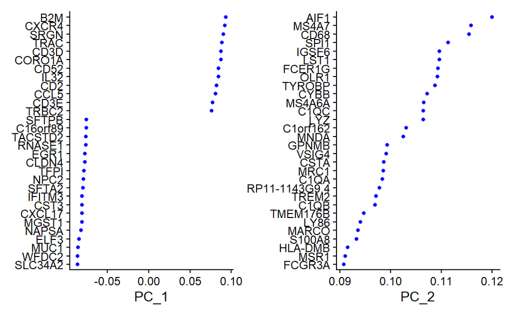

```r
VizDimLoadings(pca_rna, dims = 1:2, reduction = "pca")
```

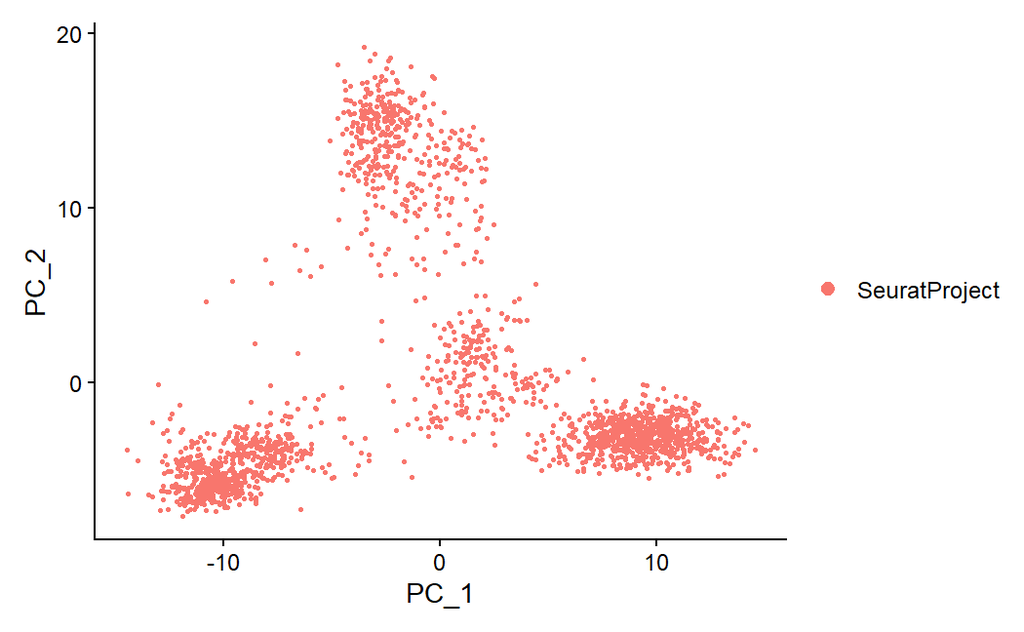

```r
DimPlot(pca_rna, reduction = "pca")
```

Now that we have the PCA of our dataset, we have to chose how many PCs to keep (ie. determine the dimension of the dataset) We’ll use the JackStraw method like in the article

```r
jackstraw <- JackStraw(pca_rna, num.replicate = 100)
```

[output not shown]

[output cut: 68 more lines]

[output not shown]

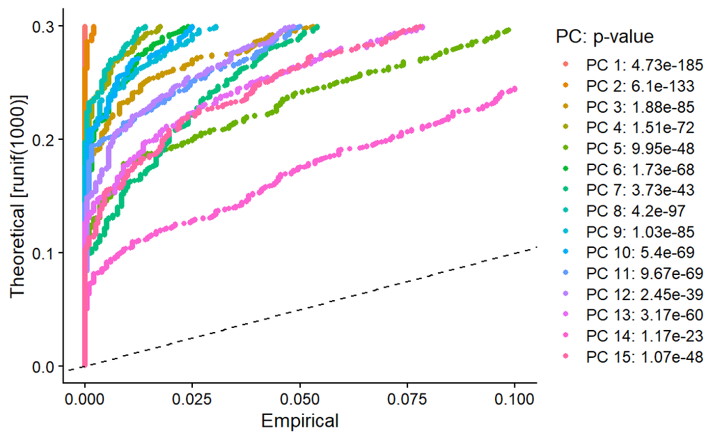

```r
jackstraw_score <- ScoreJackStraw(jackstraw, dims = 1:20)
JackStrawPlot(jackstraw_score, dims = 1:15)
```

This looks like we have a high-dimensional dataset, since the 15 first PC are clearly above the uniform distribution line.

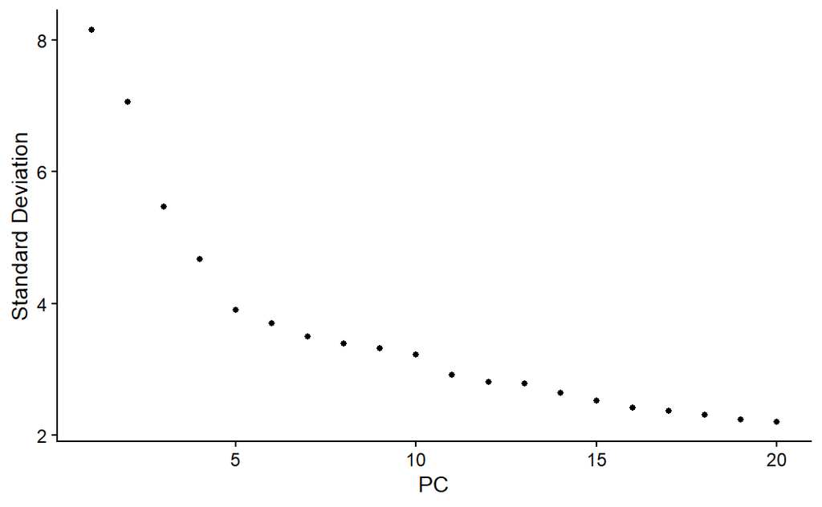

```r
ElbowPlot(jackstraw_score)
```

Here we see again that all 15 (even 20) first PC account for information. We’ll only keep the first 10 dimensions, since there is a little drop off after PC 10.

```r
neighbors <- FindNeighbors(jackstraw_score, dims = 1:10)
clusters <- FindClusters(neighbors, resolution = 0.5)
```

```
Modularity Optimizer version 1.3.0 by Ludo Waltman and Nees Jan van Eck

Number of nodes: 1955
Number of edges: 60224

Running Louvain algorithm...
```

```
Maximum modularity in 10 random starts: 0.9248
Number of communities: 13
Elapsed time: 0 seconds
```

```r
# If you haven't installed UMAP, you can do so via reticulate::py_install(packages = 'umap-learn')
umap <- RunUMAP(clusters, dims = 1:10)
```

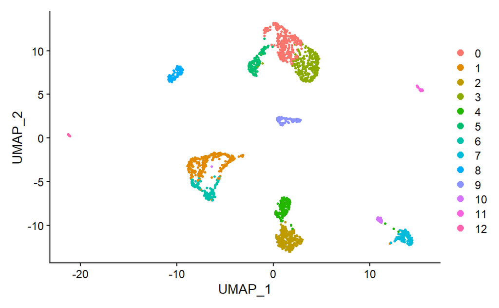

```r
DimPlot(umap, reduction = "umap")
```

```r
# find markers for every cluster compared to all remaining cells, report only the positive
# ones
umap.markers <- FindAllMarkers(umap, only.pos = TRUE, min.pct = 0.25, logfc.threshold = 0.25, test.use = "t")
```

[output not shown]

[output cut: 40 more lines]

[output not shown]

[output not shown]

[output cut: 43 more lines]

[output not shown]

[output not shown]

[output cut: 42 more lines]

[output not shown]

[output not shown]

[output cut: 31 more lines]

[output not shown]

[output not shown]

[output cut: 43 more lines]

[output not shown]

[output not shown]

[output cut: 40 more lines]

[output not shown]

[output not shown]

[output cut: 44 more lines]

[output not shown]

[output not shown]

[output cut: 43 more lines]

[output not shown]

[output not shown]

[output cut: 37 more lines]

[output not shown]

[output not shown]

[output cut: 33 more lines]

[output not shown]

[output not shown]

[output cut: 44 more lines]

[output not shown]